# Coronavirus Eploritory Data Analysis

Hayden Smedley

03/12/20

# COVID-19 Introduction

COVID-19 or Coronavirus Disease of 2019 is a disease casued by SARS-CoV-2 virus and is root of the ongoing global pandemic. At the moment, over 150,000 people have been infected, including over 2,000 in the United States, and over 5,800 people have died (World Health Organization [WHO], n.d.).

### Symptoms

The most common symptoms are a fever, tiredness, and a dry cough. Other possible symptoms include aches and pains, nasal congestion, runny nose, sore throat or diarrhea. Around one in six may develop difficulty breathing and require special treatment (World Health Organization [WHO], n.d.).

### Spread and Avoidance

The virus spreads from person to person through droplets from the nose or mouth. These droplets can land on surfaces and be touched by another person who then touches their face. The droplets can also be breathed in by another person. The best ways to avoid being infected include regularly washing your hands with soap, keeping your distance from others when possible, and avoid touching your mouth, nose, or eyes. Additionally, staying home and self-isolate when you are sick can help stop others from becoming sick (World Health Organization [WHO], n.d.).

## Data input and cleaning

In order to do anything with the data it first needs to be imported. This was done with the readxl package and the files coronavirus.xlsx and comorbidity.xlsx were imported successfully. These two files were then combined with an inner join on the ID variable. This created one file from any shared data. Lastly the data was recoded to change any age value that was greater than or equal to 120 to NA and any values of Mainland China in the country variable was changed to simply China to avoid splitting China’s data.

```r
# Import readxl package
library("readxl")
# Import dplyr package
library(dplyr)
# Set working directory
setwd("C:/Users/hayde/Documents/INST408F")

# Read in excel files with data
cv <- read_excel("Homework 1/coronavirus.xlsx")
cm <- read_excel("Homework 1/comorbidity.xlsx")

# Join data where IDs exist in both files
combined_cv <- inner_join(cv, cm, by="ID")

# Recode any age greater than or equal to 120 to NA
combined_cv$Age[combined_cv$Age >= 120] <- NA

# Recode Mainland China to China
combined_cv$Country[combined_cv$Country == "Mainland China"] <- "China"

# Summary of Coronavirus data
summary(combined_cv)
```

```
##        ID             Sex                 DOB
##  Min.   :   1.0   Length:1764        Min.   :1925-09-02 00:00:00
##  1st Qu.: 460.8   Class :character   1st Qu.:1942-05-05 12:00:00
##  Median : 901.5   Mode  :character   Median :1946-11-04 12:00:00
##  Mean   : 899.9                      Mean   :1944-08-08 13:31:26
##  3rd Qu.:1342.2                      3rd Qu.:1948-10-30 12:00:00
##  Max.   :1783.0                      Max.   :1950-08-22 00:00:00
##
##      Race            Ethnicity            FName              LName
##  Length:1764        Length:1764        Length:1764        Length:1764
##  Class :character   Class :character   Class :character   Class :character
##  Mode  :character   Mode  :character   Mode  :character   Mode  :character
##
##
##
##
##   CoronaVirus         Age          Country              Death
##  Min.   :0.000   Min.   : 2.00   Length:1764        Min.   :0.000
##  1st Qu.:0.000   1st Qu.:16.00   Class :character   1st Qu.:0.000
##  Median :0.000   Median :29.00   Mode  :character   Median :0.000
##  Mean   :0.496   Mean   :29.16                      Mean   :0.246
##  3rd Qu.:1.000   3rd Qu.:43.00                      3rd Qu.:0.000
##  Max.   :1.000   Max.   :55.00                      Max.   :1.000
##                  NA's   :3
##  Comorbidity
##  Length:1764
##  Class :character
##  Mode  :character
##
##
##
##
```

## Exploratory Data Analysis

```r
# Get the number of observations
length(combined_cv$ID)
```

```
## [1] 1764
```

```r
# Get the number of variables
length(combined_cv)
```

```
## [1] 12
```

```r
# Get proportion of patients by sex
prop.table(table(combined_cv$Sex))*100
```

```
##
##        F        M
## 49.88662 50.11338
```

```r
# Get median age of patients who have coronavirus
median(filter(combined_cv, CoronaVirus == 1)$Age, na.rm = TRUE)
```

```
## [1] 28
```

```r
# Get mean age of patients who died from coronavirus
mean(filter(combined_cv, CoronaVirus == 1 & Death == 1)$Age, na.rm = TRUE)
```

```
## [1] 28.39723
```

```r
# Get standard deviation of age of patients who died from coronavirus
sd(filter(combined_cv, CoronaVirus == 1 & Death == 1)$Age, na.rm = TRUE)
```

```
## [1] 15.92602
```

```r
# Get proportion of cases of coronavirus by country
sort(prop.table(table(filter(combined_cv, CoronaVirus == 1)$Country))*100, decreasing = TRUE)
```

```
##
##                China                   US            Australia
##           51.3142857           10.0571429            4.4571429
##               Canada               Taiwan          South Korea
##            3.6571429            2.0571429            1.7142857
##              Vietnam                Macau                Japan
##            1.7142857            1.6000000            1.4857143
##            Singapore             Thailand United Arab Emirates
##            1.4857143            1.4857143            1.4857143
##              Finland              Germany            Hong Kong
##            1.2571429            1.2571429            1.2571429
##             Malaysia              Belgium               France
##            1.2571429            1.1428571            1.1428571
##                India                Nepal               Russia
##            1.1428571            1.1428571            1.1428571
##                   UK          Philippines            Sri Lanka
##            1.1428571            0.9142857            0.9142857
##               Sweden             Cambodia               Others
##            0.9142857            0.8000000            0.8000000
##                Spain                Italy                Egypt
##            0.6857143            0.4571429            0.1142857
```

```r
# Get proportion of comorbidities associated with coronavirus patients
sort(prop.table(table(filter(combined_cv, CoronaVirus == 1)$Comorbidity))*100, decreasing = TRUE)
```

```
##
##          None         Lupus           HIV Heart Disease Liver Disease
##     71.314286     15.314286      7.542857      3.885714      1.942857
```

## Data Visualization

The boxplot below represents Patient Age by Coronavirus Positivity. The left box plot shows the distribution of the ages of patients who do not have coronavirus while the right box plot shows the same for the patients who do have coronavirus. The distribution is fairly similar in both groups, with patients without coronavirus having a slightly tighter central distribution and higher median.

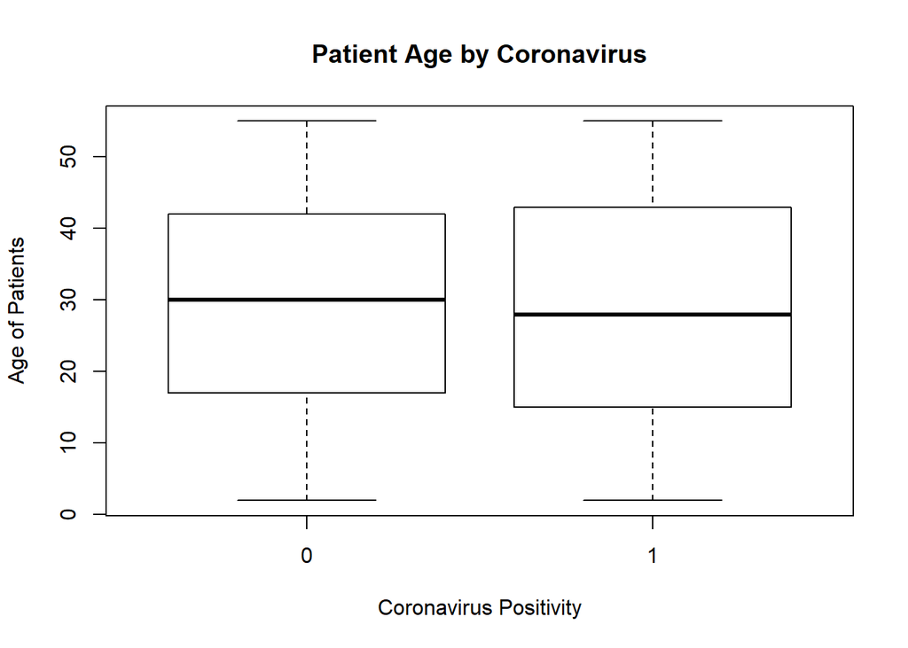

```r
# Create boxplot of age by coronavirus
boxplot(Age~CoronaVirus,data=combined_cv, main="Patient Age by Coronavirus", ylab="Age of Patients", xlab="Coronavirus Positivity")
```

# Biblography

- Q&A on coronaviruses (COVID-19). (n.d.). Retrieved March 12, 2020, from https://www.who.int/news-room/q-a-detail/q-a-coronaviruses
- Coronavirus disease 2019. (n.d.). Retrieved March 12, 2020, from https://www.who.int/emergencies/diseases/novel-coronavirus-2019